# Proyecto Fin de Master

Lucía Rico Cuéllar

08 de julio de 2017

Se presentan gráficas de predicción de intervalos de 5 años para 2 autopistas de prueba con diferente patrón, y se observa que a partir del tercer año empeoran las predicciones en todos los modelos de ambas autopistas, por lo que finalmente se elige un periodo de predicción de 2 años:

## Lectura y limpieza de datos

Empezamos analizando la autopista : `06020101_montmelo_la_junquera.csv` Vamos a analizar con y sin aplicar logaritmos en base 10.

## Estudio de los datos sin logartimos

Creo serie temporal y la pinto completa:

```r
nombre_elegido <- "06020101_montmelo_la_junquera"
autopista <- autopista_TODAS %>% filter(nombre == nombre_elegido)
autopista <- autopista[, 1:2]

ts_mensual <- ts(autopista$IMD_total, start=c(1990, 1), end=c(2017, 3), frequency=12)
xts_mensual <- as_xts(autopista, date_col = Mes_numeric)
```

Para poder inspeccionar el detalle de los valores en la propia gráfica y hacer zoom:

```r
highchart(type = "stock") %>%
  hc_title(text = "Time Serie") %>%
  hc_subtitle(text = nombre_elegido) %>%
  hc_add_series(ts_mensual, name = "IMD") %>%
  hc_rangeSelector(inputEnabled = TRUE) %>%
  hc_scrollbar(enabled = TRUE) %>%
  hc_add_theme(hc_theme_gridlight())
```

[interactive chart not shown]

Resumen de estadísticas básicas de los datos:

```r
summary(xts_mensual)
```

```
##      Index       xts_mensual
##  Min.   :1990   Min.   :19110
##  1st Qu.:1997   1st Qu.:29142
##  Median :2004   Median :36706
##  Mean   :2004   Mean   :37530
##  3rd Qu.:2010   3rd Qu.:43718
##  Max.   :2017   Max.   :68198
```

### Descomposición estacional

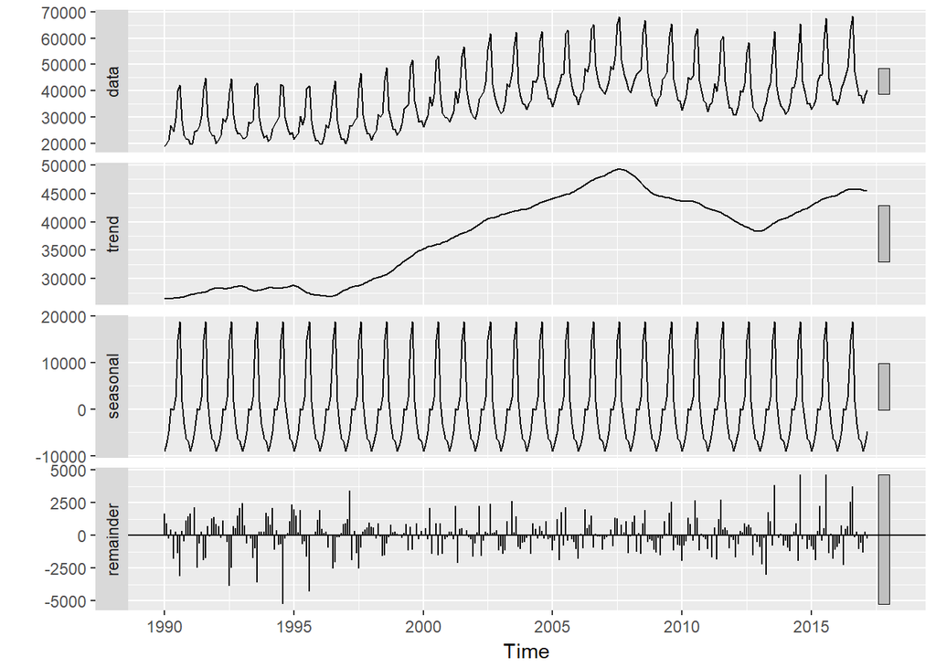

```r
ts_mensual <- ts(autopista$IMD_total, start=c(1990, 1), end=c(2017, 3), frequency=12)
autoplot(stl(ts_mensual, s.window="period"))
```

Intervalo de test 5 años:

```r
train <- window(ts_mensual, start=c(1990, 01), end=c(2011, 12))
test <- window(ts_mensual, start=c(2012, 01), end=c(2016, 12))
highchart(type = "stock") %>%
  hc_title(text = "Conjuntos de entrenamiento y testeo") %>%
  hc_subtitle(text = "Divido los datos totales en los conjuntos train y test") %>%
  hc_add_series(train, name = "train") %>%
  hc_add_series(test, name = "test") %>%
  hc_rangeSelector(inputEnabled = TRUE) %>%
  hc_scrollbar(enabled = TRUE) %>%
  hc_add_theme(hc_theme_gridlight())
```

[interactive chart not shown]

### Modelado exponencial ETS y predicción

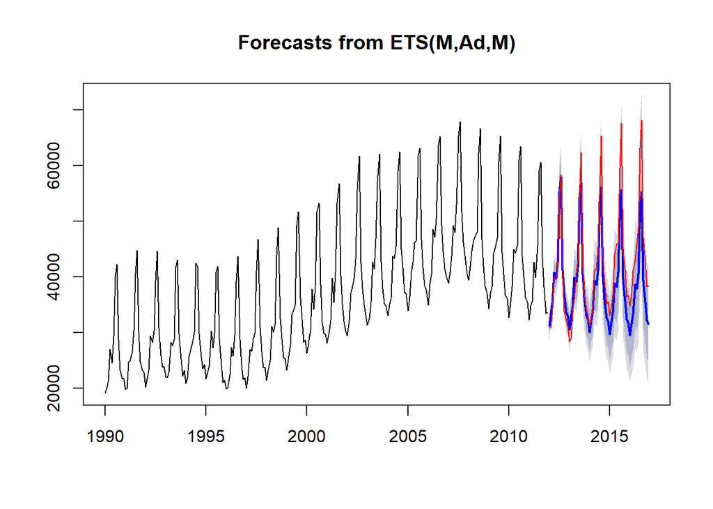

```r
fit_ets <- ets(train)
prediccion_ets <- forecast(fit_ets, h=5*12)
par(mfrow=c(1,1))
plot(prediccion_ets)
lines(test, col="red")
```

### Modelado ARIMA y predicción:

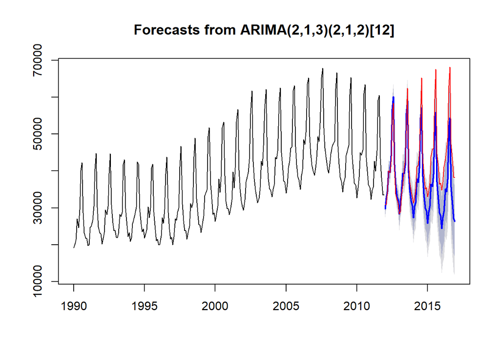

```r
fit_arima <- auto.arima(train)
prediccion_arima <- forecast(fit_arima, h=5*12)
par(mfrow=c(1,1))
plot(prediccion_arima)
lines(test, col="red")
```

## Voy a probar a hacer lo mismo pero aplicando primero log:

Creo serie temporal:

```r
log_xts_mensual <- round(log10(ts_mensual), 2)
highchart(type = "stock") %>%
  hc_title(text = "Time Serie") %>%
  hc_subtitle(text = nombre_elegido) %>%
  hc_add_series(log_xts_mensual, name = "IMD") %>%
  hc_rangeSelector(inputEnabled = TRUE) %>%
  hc_scrollbar(enabled = TRUE) %>%
  hc_add_theme(hc_theme_gridlight())
```

[interactive chart not shown]

Resumen de estadísticas básicas de los datos:

```r
summary(log_xts_mensual)
```

```
##    Min. 1st Qu.  Median    Mean 3rd Qu.    Max.
##   4.280   4.465   4.560   4.555   4.640   4.830
```

### Descomposición estacional:

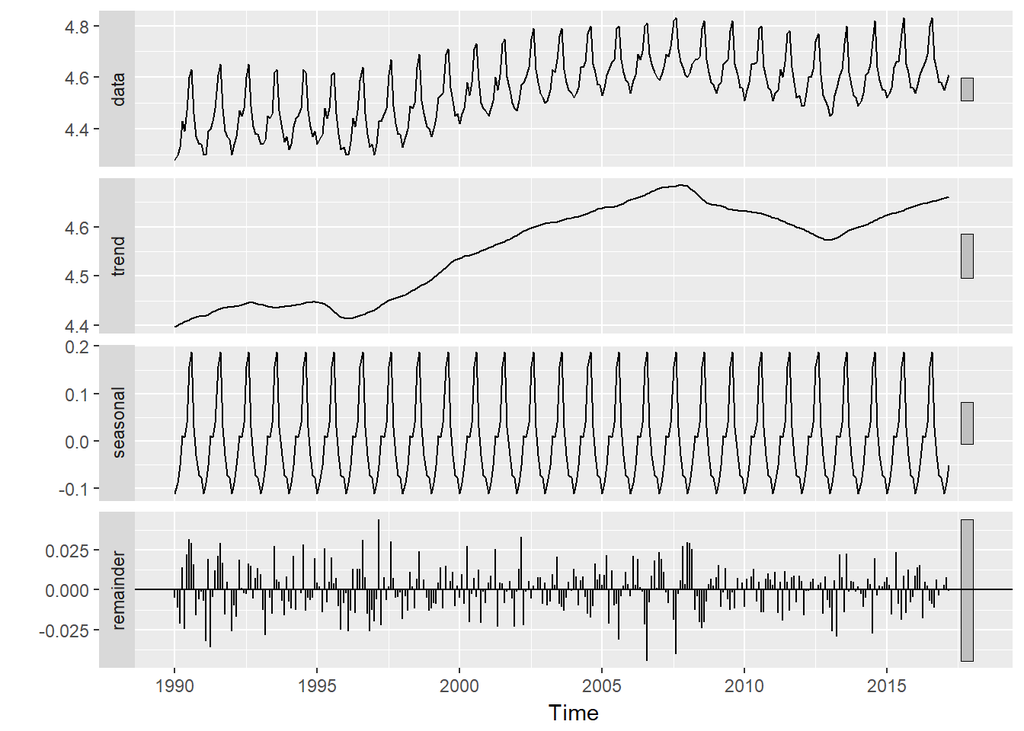

```r
autoplot(stl(log_xts_mensual, s.window="period"))
```

```r
train_log <- window(log_xts_mensual, start=c(1990, 01), end=c(2011, 12))
test_log <- window(log_xts_mensual, start=c(2012, 01), end=c(2016, 12))
highchart(type = "stock") %>%
  hc_title(text = "Conjuntos de entrenamiento y testeo") %>%
  hc_subtitle(text = "Divido los datos totales en los conjuntos train y test") %>%
  hc_add_series(train_log, name = "train") %>%
  hc_add_series(test_log, name = "test") %>%
  hc_rangeSelector(inputEnabled = TRUE) %>%
  hc_scrollbar(enabled = TRUE) %>%
  hc_add_theme(hc_theme_gridlight())
```

[interactive chart not shown]

### Modelado exponencial ETS y predicción

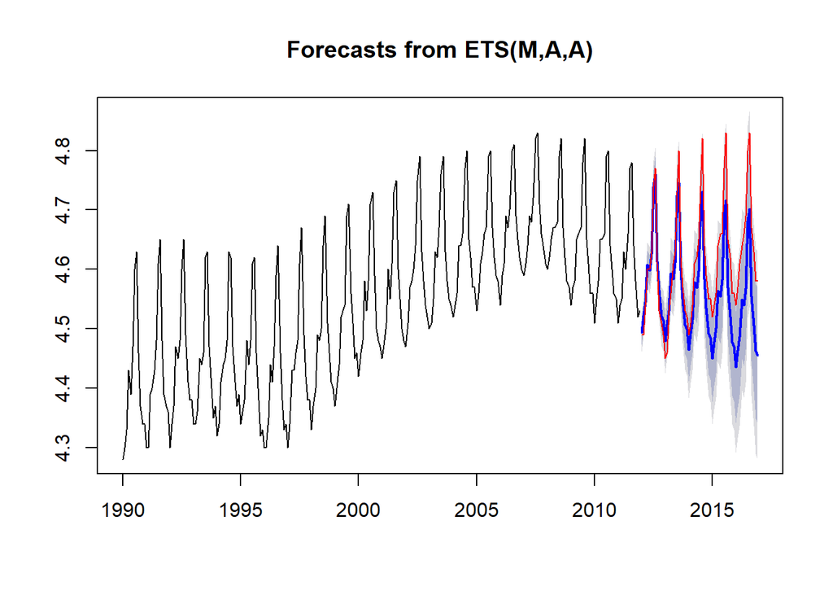

```r
fit_ets_log <- ets(train_log)
prediccion_ets_log <- forecast(fit_ets_log, h=12*5)
par(mfrow=c(1,1))
plot(prediccion_ets_log )
lines(test_log, col="red")
```

### Modelado ARIMA y predicción:

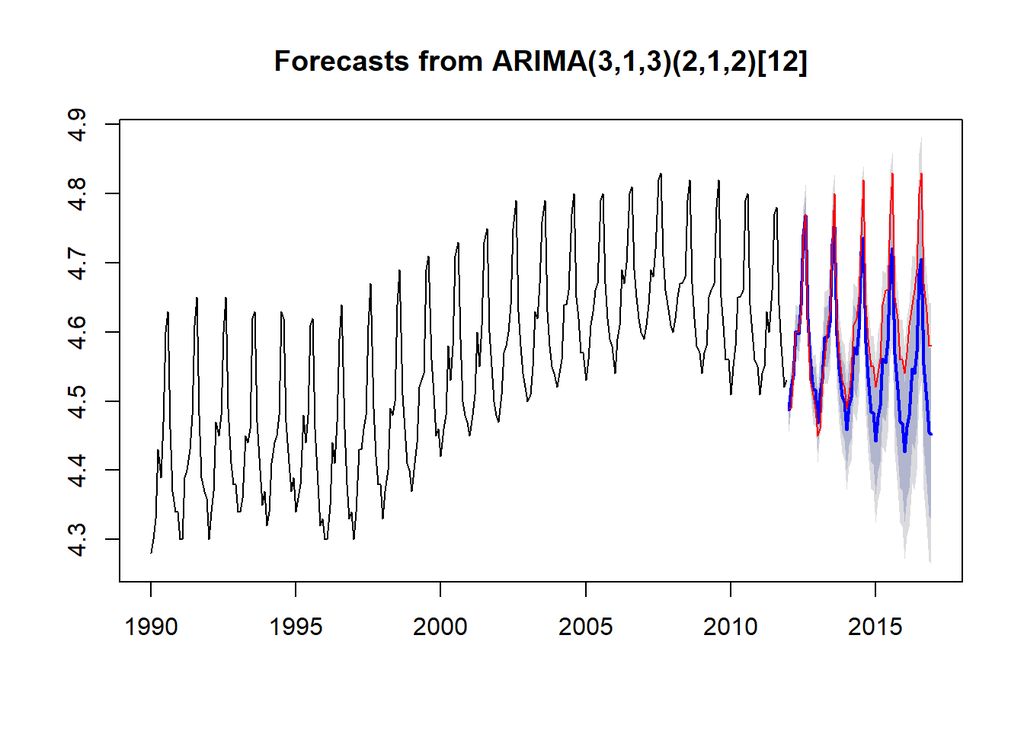

```r
fit_arima_log <- auto.arima(train_log)
prediccion_arima_log <- forecast(fit_arima_log, h=12*5)
plot(prediccion_arima_log)
lines(test_log, col="red")
```

Analizamos ahora la autopista : `06020701_madrid_guadalajara` Vamos a analizar con y sin aplicar logaritmos en base 10.

## Lectura y limpieza de datos

## Estudio de los datos sin logartimos

Creo serie temporal y la pinto completa:

```r
ts_mensual <- ts(autopista$IMD_total, start=c(1990, 1), end=c(2017, 3), frequency=12)
xts_mensual <- as_xts(autopista, date_col = Mes_numeric)
```

Para poder inspeccionar el detalle de los valores en la propia gráfica y hacer zoom:

```r
highchart(type = "stock") %>%
  hc_title(text = "Time Serie") %>%
  hc_subtitle(text = nombre_elegido) %>%
  hc_add_series(ts_mensual, name = "IMD") %>%
  hc_rangeSelector(inputEnabled = TRUE) %>%
  hc_scrollbar(enabled = TRUE) %>%
  hc_add_theme(hc_theme_gridlight())
```

[interactive chart not shown]

Resumen de estadísticas básicas de los datos:

```r
summary(xts_mensual)
```

```
##      Index       xts_mensual
##  Min.   :2004   Min.   : 3614
##  1st Qu.:2007   1st Qu.: 4924
##  Median :2010   Median : 7061
##  Mean   :2010   Mean   : 7292
##  3rd Qu.:2014   3rd Qu.: 9498
##  Max.   :2017   Max.   :12991
```

### Descomposición estacional

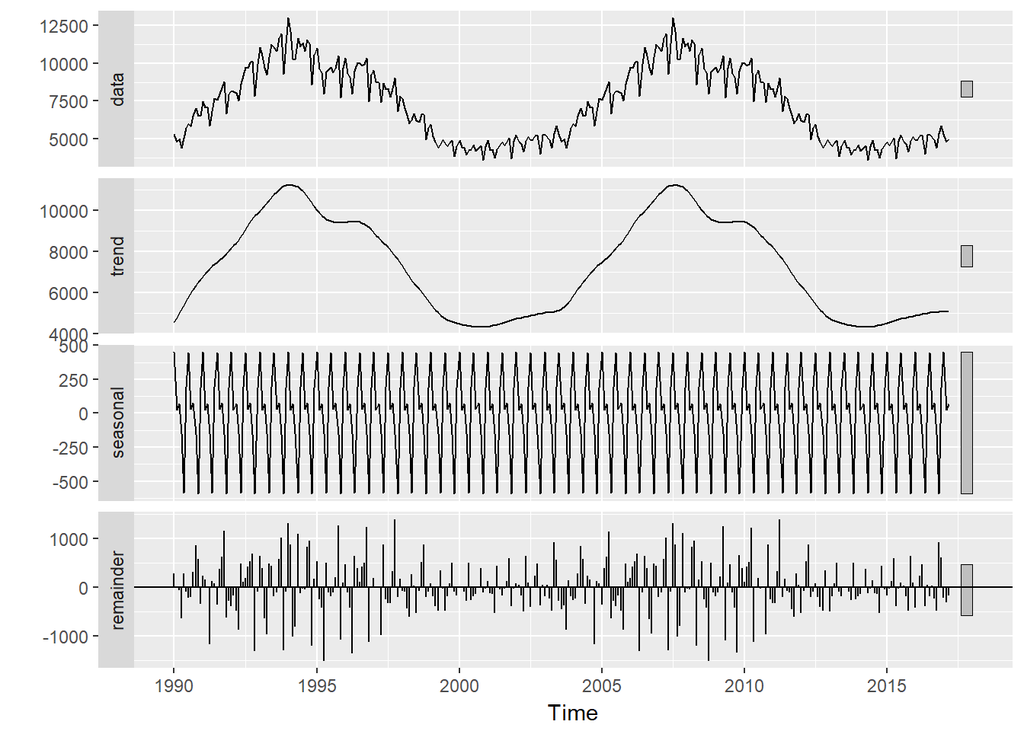

```r
ts_mensual <- ts(autopista$IMD_total, start=c(1990, 1), end=c(2017, 3), frequency=12)
autoplot(stl(ts_mensual, s.window="period"))
```

Intervalo de test 5 años:

```r
train <- window(ts_mensual, start=c(1990, 01), end=c(2011, 12))
test <- window(ts_mensual, start=c(2012, 01), end=c(2016, 12))
highchart(type = "stock") %>%
  hc_title(text = "Conjuntos de entrenamiento y testeo") %>%
  hc_subtitle(text = "Divido los datos totales en los conjuntos train y test") %>%
  hc_add_series(train, name = "train") %>%
  hc_add_series(test, name = "test") %>%
  hc_rangeSelector(inputEnabled = TRUE) %>%
  hc_scrollbar(enabled = TRUE) %>%
  hc_add_theme(hc_theme_gridlight())
```

[interactive chart not shown]

### Modelado exponencial ETS y predicción

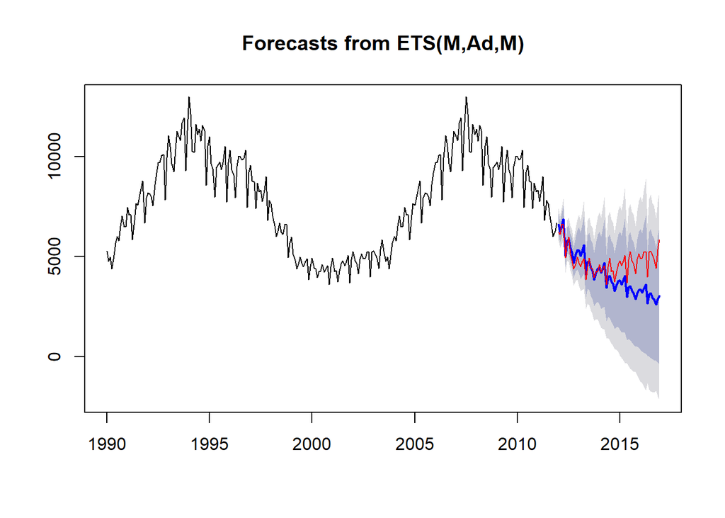

```r
fit_ets <- ets(train)
prediccion_ets <- forecast(fit_ets, h=5*12)
par(mfrow=c(1,1))
plot(prediccion_ets)
lines(test, col="red")
```

### Modelado ARIMA y predicción:

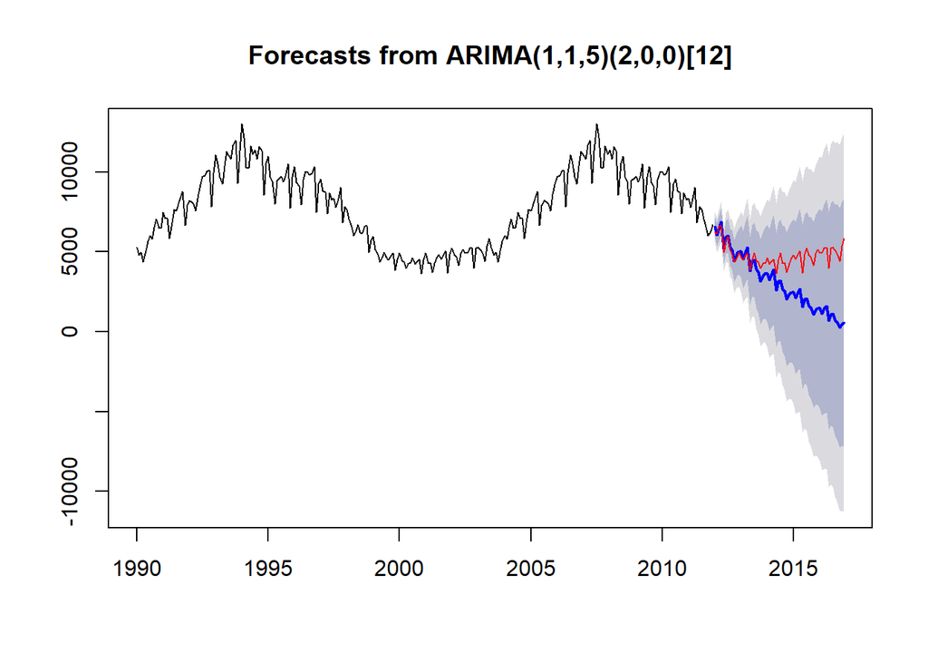

```r
fit_arima <- auto.arima(train)
prediccion_arima <- forecast(fit_arima, h=5*12)
par(mfrow=c(1,1))
plot(prediccion_arima)
lines(test, col="red")
```

## Voy a probar a hacer lo mismo pero aplicando primero log:

Creo serie temporal:

```r
log_xts_mensual <- round(log10(ts_mensual), 2)
highchart(type = "stock") %>%
  hc_title(text = "Time Serie") %>%
  hc_subtitle(text = nombre_elegido) %>%
  hc_add_series(log_xts_mensual, name = "IMD") %>%
  hc_rangeSelector(inputEnabled = TRUE) %>%
  hc_scrollbar(enabled = TRUE) %>%
  hc_add_theme(hc_theme_gridlight())
```

[interactive chart not shown]

Resumen de estadísticas básicas de los datos:

```r
summary(log_xts_mensual)
```

```
##    Min. 1st Qu.  Median    Mean 3rd Qu.    Max.
##   3.560   3.690   3.850   3.836   3.980   4.110
```

### Descomposición estacional:

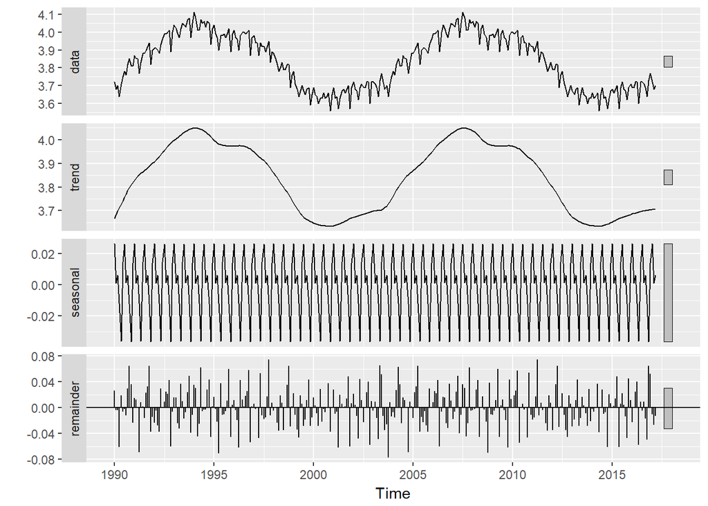

```r
autoplot(stl(log_xts_mensual, s.window="period"))
```

```r
train_log <- window(log_xts_mensual, start=c(1990, 01), end=c(2011, 12))
test_log <- window(log_xts_mensual, start=c(2012, 01), end=c(2016, 12))
highchart(type = "stock") %>%
  hc_title(text = "Conjuntos de entrenamiento y testeo") %>%
  hc_subtitle(text = "Divido los datos totales en los conjuntos train y test") %>%
  hc_add_series(train_log, name = "train") %>%
  hc_add_series(test_log, name = "test") %>%
  hc_rangeSelector(inputEnabled = TRUE) %>%
  hc_scrollbar(enabled = TRUE) %>%
  hc_add_theme(hc_theme_gridlight())
```

[interactive chart not shown]

### Modelado exponencial ETS y predicción

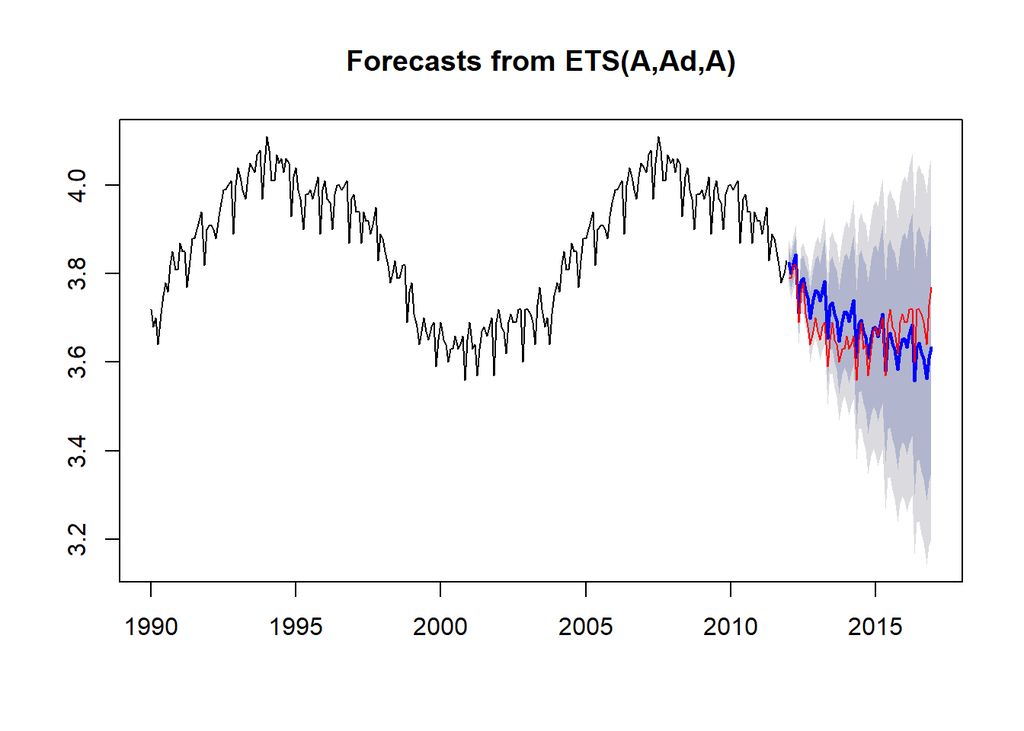

```r
fit_ets_log <- ets(train_log)
prediccion_ets_log <- forecast(fit_ets_log, h=12*5)
par(mfrow=c(1,1))
plot(prediccion_ets_log )
lines(test_log, col="red")
```

### Modelado ARIMA y predicción:

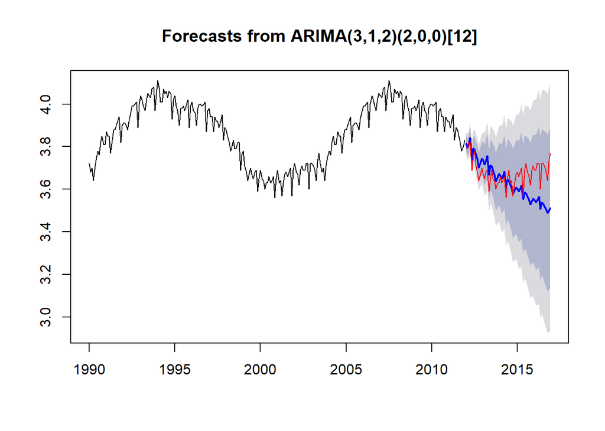

```r
fit_arima_log <- auto.arima(train_log)
prediccion_arima_log <- forecast(fit_arima_log, h=12*5)
plot(prediccion_arima_log)
lines(test_log, col="red")
```

### Conclusiones:

Se observa claramente en todos los modelos que a partir del tercer año las predicciones se desvían del conjunto de test.